# Land Surface Temperature from Landsat 5 and 7 images

Zuhayr Shahid Ishmam

8/5/2022

## Load required libraries

```r
library(raster)
library(RStoolbox)
library(SciViews)
library(RColorBrewer)
library(extremevalues)
library(rgdal)
```

## Load Metadata and Stack all the bands of the satellite image. View RGB of the entire image.

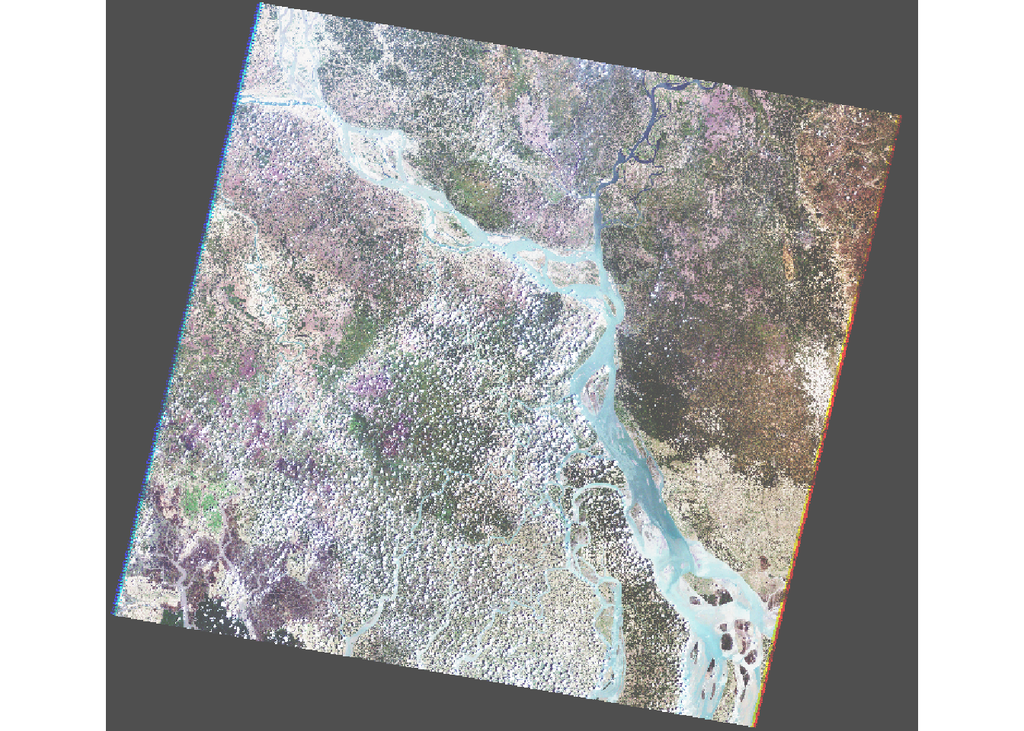

```r
metaData <- read.delim("C:/WORK/CUET_2022_CONF/satellite_images_LST/2001/LE07_L1TP_137044_20010419_20170205_01_T1/LE07_L1TP_137044_20010419_20170205_01_T1_MTL.txt",
                       sep = '=', stringsAsFactors = F)

Lsat <- stackMeta("C:/WORK/CUET_2022_CONF/satellite_images_LST/2001/LE07_L1TP_137044_20010419_20170205_01_T1/LE07_L1TP_137044_20010419_20170205_01_T1_MTL.txt")

plotRGB(Lsat, r = 3, g = 2, b = 1, stretch = "hist")
```

Here, “C:/WORK/CUET_2022_CONF/satellite_images_LST/2001/LE07_L1TP_137044_20010419_20170205_01_T1/” is the directory where the satellite image bands are located. “LE07_L1TP_137044_20010419_20170205_01_T1_MTL.txt” is the metadata file.

## Load the shapefile of the area of interest, crop & mask and plot .

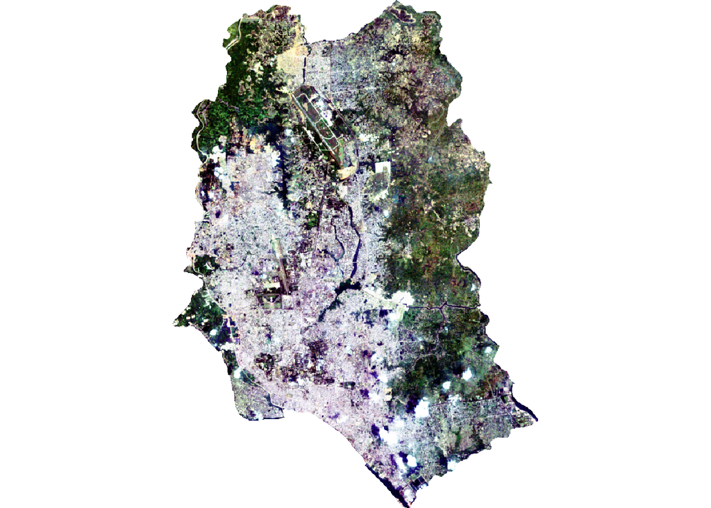

```r
shape <- shapefile("DCC_UTM_46N.shp")
Lsat_shape <- crop(Lsat, extent(shape))
Lsat_shape <- mask(Lsat_shape, shape)
plotRGB(Lsat_shape, r = 3, g = 2, b = 1, stretch = "hist")
```

## Required formula for LST calculation

1. Spectral_Radiance_L = ((Lmax-Lmin)/(QCalmax-QCalmin)) * (Lsat_shape$B6_dn - QCalmin) + Lmin
2. At_satellite_temp = K2/ (ln((K1/Spectral_Radiance_L)+1))
3. Surface_temp = (At_satellite_temp/(1+(waveLen*At_satellite_temp/rho)* ln(emissivity))) - 273.15

emissivity = 0.004* Pv + 0.986

Pv = (NDVI - minValue(NDVI))/(maxValue(NDVI) - minValue(NDVI))**2

## Reading required values from the metadata. The code is slightly changed for Landsat -5. (omit VCID_1)

Wave length of the emitted radiance for Band six (thermal band) is taken as the average of of 10.4 & 12.5. Rho = 14388 (constant)

```r
waveLen <- 11.4
rho<- 14388

Lmax <- as.numeric(metaData[grep('RADIANCE_MAXIMUM_BAND_6_VCID_1', metaData$GROUP),]$L1_METADATA_FILE)
Lmin <- as.numeric(metaData[grep('RADIANCE_MINIMUM_BAND_6_VCID_1', metaData$GROUP),]$L1_METADATA_FILE)

QCalmax <- as.numeric(metaData[grep('QUANTIZE_CAL_MAX_BAND_6_VCID_1', metaData$GROUP),]$L1_METADATA_FILE)
QCalmin <- as.numeric(metaData[grep('QUANTIZE_CAL_MIN_BAND_6_VCID_1', metaData$GROUP),]$L1_METADATA_FILE)

K2 <- as.numeric(metaData[grep('K2_CONSTANT_BAND_6_VCID_1', metaData$GROUP),]$L1_METADATA_FILE)
K1 <- as.numeric(metaData[grep('K1_CONSTANT_BAND_6_VCID_1', metaData$GROUP),]$L1_METADATA_FILE)
```

## Calculating Spectral Radiance and At-Satellite Temperature. The code is slightly changed for Landsat -5. (omit VCID_1)

```r
Spectral_Radiance_L <- ((Lmax-Lmin)/(QCalmax-QCalmin)) * (Lsat_shape$B6_VCID_1_dn - QCalmin) + Lmin
At_satellite_temp <- K2/ (ln((K1/Spectral_Radiance_L)+1))
```

## Calculating the At-Surface Temperature

## NDVI Calculation

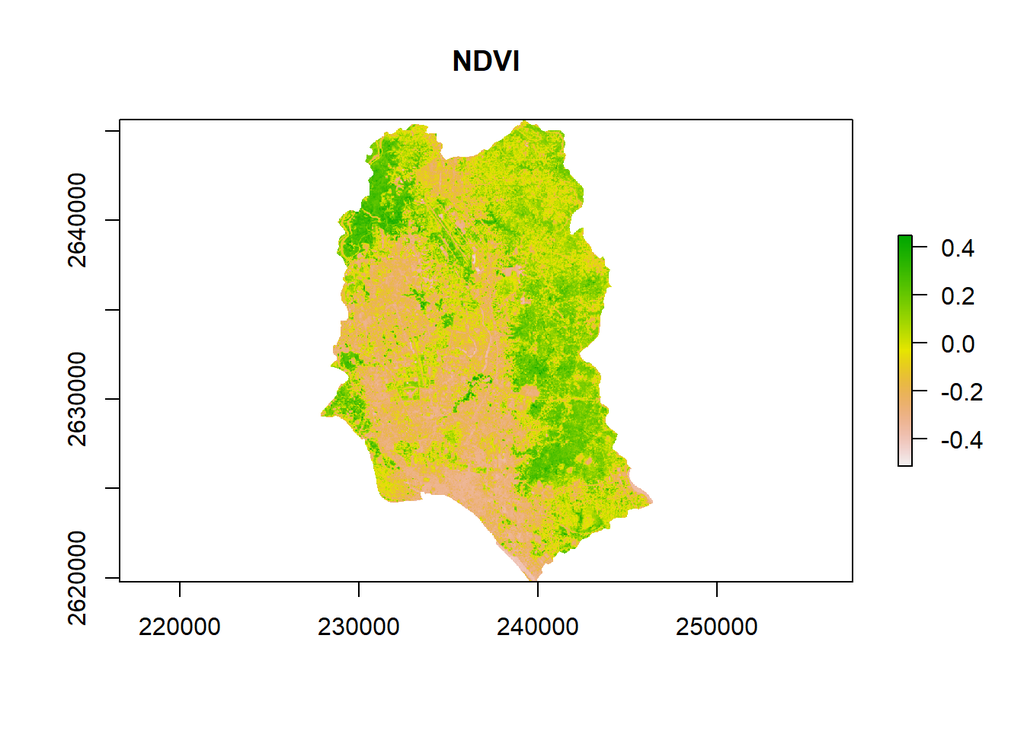

```r
Lsat_shape_ndvi <- spectralIndices(Lsat_shape, red = "B3_dn", nir = "B4_dn", indices = "NDVI")
plot(Lsat_shape_ndvi, main = "NDVI")
```

## Proportion of Vegetation and Emissivity

```r
Pv<-(Lsat_shape_ndvi - minValue(Lsat_shape_ndvi))/(maxValue(Lsat_shape_ndvi) - minValue(Lsat_shape_ndvi))**2

emissivity <- 0.004* Pv + 0.986
```

## Calculating At-Surface Temperature and Plot

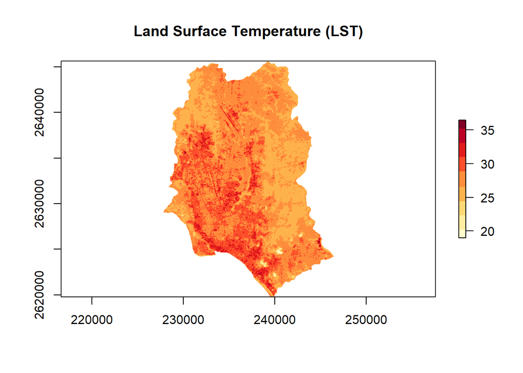

```r
Surface_temp<-(At_satellite_temp/(1+(waveLen*At_satellite_temp/rho)* ln(emissivity))) - 273.15
plot(Surface_temp, col=brewer.pal(9,"YlOrRd"), main = "Land Surface Temperature (LST)")
```

## Reclassify the LST Raster

```r
reclass_df <- c(-Inf, 26, 1,
                26, 29, 2,
                29, 32, 3,
                32, Inf, 4)


reclass_matrix <- matrix(reclass_df,
                    ncol = 3,
                    byrow = TRUE)

reclass_matrix
```

```
##      [,1] [,2] [,3]
## [1,] -Inf   26    1
## [2,]   26   29    2
## [3,]   29   32    3
## [4,]   32  Inf    4
```

```r
LST_classified <- reclassify(Surface_temp,
                             reclass_matrix)
```

## View number of Pixels in each category

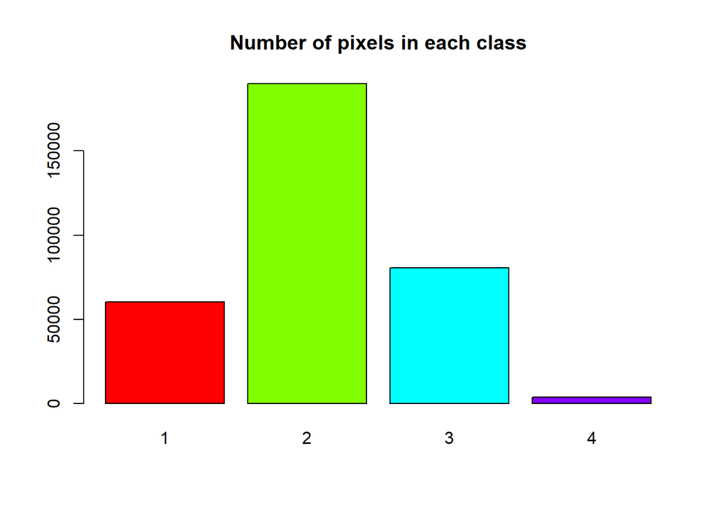

```r
barplot(LST_classified,
        main = "Number of pixels in each class")
```

```r
freq(LST_classified)
```

```
##      value  count
## [1,]     1  60161
## [2,]     2 190033
## [3,]     3  80453
## [4,]     4   3748
## [5,]    NA 199425
```

## Plot Re-classified data

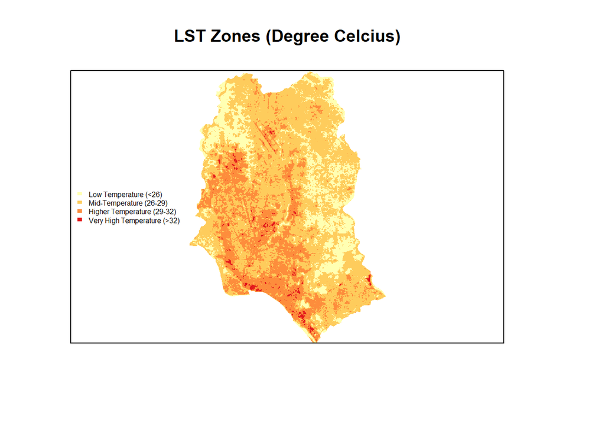

```r
plot(LST_classified,
     legend = FALSE,
     col = brewer.pal(4,"YlOrRd"), axes = FALSE,
     main = "LST Zones (Degree Celcius)")

legend("left",
       legend = c("Low Temperature (<26)", "Mid-Temperature (26-29)",
                  "Higher Temperature (29-32)", "Very High Temperature (>32)"),
       fill = brewer.pal(4,"YlOrRd"), cex= 0.5,
       border = FALSE,
       bty = "n")
```

```r
#writeRaster(LST_classified,'LST_classified.tif')
```